# Prediction of the accident possibility for carsharing company

```python
ttl_model_df.info()
```

```
<class 'pandas.core.frame.DataFrame'>
RangeIndex: 246125 entries, 0 to 246124
Data columns (total 12 columns):
 #   Column                  Non-Null Count   Dtype
---  ------                  --------------   -----
 0   collision_damage        246125 non-null  object
 1   pcf_violation_category  242012 non-null  object
 2   type_of_collision       244631 non-null  object
 3   road_surface            244160 non-null  object
 4   lighting                245264 non-null  object
 5   control_device          244923 non-null  object
 6   vehicle_age             240096 non-null  float64
 7   at_fault                246125 non-null  int64
 8   insurance_premium       229970 non-null  float64
 9   party_sobriety          241127 non-null  object
 10  party_drug_physical     246125 non-null  object
 11  cellphone_in_use        213747 non-null  float64
dtypes: float64(3), int64(1), object(8)
memory usage: 22.5+ MB
```

**Deletion of nulls**

```python
ttl_model_df = ttl_model_df.dropna()
```

```python
target = ttl_model_df['at_fault']
```

```python
# Selection of categorical and numeric columns
numeric_col = list(ttl_model_df.select_dtypes(include=['int64', 'float64']).columns[:])
numeric_col.remove('at_fault')
categorical_col = list(ttl_model_df.select_dtypes(include=['object']).columns[:])
print('Numerical columns:', numeric_col,'\n')
print('Categorical columns:','\n',categorical_col,'\n')
```

```
Numerical columns: ['vehicle_age', 'insurance_premium', 'cellphone_in_use']

Categorical columns:
 ['collision_damage', 'pcf_violation_category', 'type_of_collision', 'road_surface', 'lighting', 'control_device', 'party_sobriety', 'party_drug_physical']
```

**Splitting the data on samples**

```python
X_train_for_coding, X_valid_for_coding, y_train, y_valid = train_test_split(ttl_model_df.drop(columns = ['at_fault']), ttl_model_df['at_fault'], test_size=0.4, random_state=42)
```

**Rescaling the numeric columns**

```python
numeric_col
```

```
['vehicle_age', 'insurance_premium', 'cellphone_in_use']
```

```python
scaler = MinMaxScaler()
```

```python
scaler.fit(X_train_for_coding[numeric_col])
X_train_numeric = pd.DataFrame(scaler.transform(X_train_for_coding[numeric_col]),columns = X_train_for_coding[numeric_col].columns)
X_valid_numeric = pd.DataFrame(scaler.transform(X_valid_for_coding[numeric_col]),columns = X_valid_for_coding[numeric_col].columns)
```

```python
X_train_numeric.head(10)
```

|  | vehicle_age | insurance_premium | cellphone_in_use |
| --- | --- | --- | --- |
| 0 | 0.012422 | 0.504762 | 0.0 |
| 1 | 0.043478 | 0.714286 | 0.0 |
| 2 | 0.074534 | 0.371429 | 0.0 |
| 3 | 0.031056 | 0.266667 | 0.0 |
| 4 | 0.049689 | 0.314286 | 0.0 |
| 5 | 0.006211 | 0.342857 | 0.0 |
| 6 | 0.037267 | 0.390476 | 0.0 |
| 7 | 0.049689 | 0.380952 | 0.0 |
| 8 | 0.018634 | 0.361905 | 0.0 |
| 9 | 0.043478 | 0.438095 | 0.0 |

```python
X_train_numeric.info()
```

```
<class 'pandas.core.frame.DataFrame'>
RangeIndex: 116333 entries, 0 to 116332
Data columns (total 3 columns):
 #   Column             Non-Null Count   Dtype
---  ------             --------------   -----
 0   vehicle_age        116333 non-null  float64
 1   insurance_premium  116333 non-null  float64
 2   cellphone_in_use   116333 non-null  float64
dtypes: float64(3)
memory usage: 2.7 MB
```

```python
X_valid_numeric.head(10)
```

|  | vehicle_age | insurance_premium | cellphone_in_use |
| --- | --- | --- | --- |
| 0 | 0.068323 | 0.342857 | 0.0 |
| 1 | 0.012422 | 0.171429 | 0.0 |
| 2 | 0.043478 | 0.447619 | 0.0 |
| 3 | 0.031056 | 0.380952 | 0.0 |
| 4 | 0.024845 | 0.304762 | 0.0 |
| 5 | 0.024845 | 0.504762 | 0.0 |
| 6 | 0.031056 | 0.361905 | 0.0 |
| 7 | 0.031056 | 0.409524 | 0.0 |
| 8 | 0.012422 | 0.619048 | 0.0 |
| 9 | 0.031056 | 0.657143 | 0.0 |

```python
X_valid_numeric.info()
```

```
<class 'pandas.core.frame.DataFrame'>
RangeIndex: 77556 entries, 0 to 77555
Data columns (total 3 columns):
 #   Column             Non-Null Count  Dtype
---  ------             --------------  -----
 0   vehicle_age        77556 non-null  float64
 1   insurance_premium  77556 non-null  float64
 2   cellphone_in_use   77556 non-null  float64
dtypes: float64(3)
memory usage: 1.8 MB
```

**Encoding of categorical features**

```python
ohe = OneHotEncoder()
X_train_categorical = ohe.fit_transform(X_train_for_coding[categorical_col]).toarray()
X_valid_categorical = ohe.transform(X_valid_for_coding[categorical_col]).toarray()
```

```python
X_train_categorical = pd.DataFrame(X_train_categorical)
X_valid_categorical = pd.DataFrame(X_valid_categorical)
```

```python
X_train_categorical.head()
```

|  | 0 | 1 | 2 | 3 | 4 | 5 | 6 | 7 | 8 | 9 | ... | 48 | 49 | 50 | 51 | 52 | 53 | 54 | 55 | 56 | 57 |
| --- | --- | --- | --- | --- | --- | --- | --- | --- | --- | --- | --- | --- | --- | --- | --- | --- | --- | --- | --- | --- | --- |
| 0 | 0.0 | 0.0 | 0.0 | 0.0 | 1.0 | 0.0 | 0.0 | 0.0 | 0.0 | 0.0 | ... | 0.0 | 0.0 | 1.0 | 0.0 | 0.0 | 1.0 | 0.0 | 0.0 | 0.0 | 0.0 |
| 1 | 0.0 | 0.0 | 1.0 | 0.0 | 0.0 | 1.0 | 0.0 | 0.0 | 0.0 | 0.0 | ... | 0.0 | 0.0 | 1.0 | 0.0 | 0.0 | 1.0 | 0.0 | 0.0 | 0.0 | 0.0 |
| 2 | 0.0 | 0.0 | 1.0 | 0.0 | 0.0 | 0.0 | 0.0 | 0.0 | 0.0 | 0.0 | ... | 0.0 | 0.0 | 1.0 | 0.0 | 0.0 | 1.0 | 0.0 | 0.0 | 0.0 | 0.0 |
| 3 | 0.0 | 0.0 | 1.0 | 0.0 | 0.0 | 0.0 | 0.0 | 0.0 | 0.0 | 0.0 | ... | 0.0 | 0.0 | 1.0 | 0.0 | 0.0 | 1.0 | 0.0 | 0.0 | 0.0 | 0.0 |
| 4 | 0.0 | 1.0 | 0.0 | 0.0 | 0.0 | 1.0 | 0.0 | 0.0 | 0.0 | 0.0 | ... | 0.0 | 0.0 | 1.0 | 0.0 | 0.0 | 1.0 | 0.0 | 0.0 | 0.0 | 0.0 |

5 rows × 58 columns

```python
X_valid_categorical.head()
```

|  | 0 | 1 | 2 | 3 | 4 | 5 | 6 | 7 | 8 | 9 | ... | 48 | 49 | 50 | 51 | 52 | 53 | 54 | 55 | 56 | 57 |
| --- | --- | --- | --- | --- | --- | --- | --- | --- | --- | --- | --- | --- | --- | --- | --- | --- | --- | --- | --- | --- | --- |
| 0 | 0.0 | 0.0 | 1.0 | 0.0 | 0.0 | 0.0 | 0.0 | 0.0 | 0.0 | 0.0 | ... | 0.0 | 0.0 | 1.0 | 0.0 | 0.0 | 1.0 | 0.0 | 0.0 | 0.0 | 0.0 |
| 1 | 0.0 | 0.0 | 1.0 | 0.0 | 0.0 | 0.0 | 0.0 | 0.0 | 0.0 | 0.0 | ... | 0.0 | 0.0 | 1.0 | 0.0 | 0.0 | 1.0 | 0.0 | 0.0 | 0.0 | 0.0 |
| 2 | 0.0 | 0.0 | 1.0 | 0.0 | 0.0 | 0.0 | 0.0 | 0.0 | 0.0 | 0.0 | ... | 0.0 | 0.0 | 1.0 | 0.0 | 0.0 | 1.0 | 0.0 | 0.0 | 0.0 | 0.0 |
| 3 | 0.0 | 0.0 | 1.0 | 0.0 | 0.0 | 0.0 | 0.0 | 0.0 | 0.0 | 0.0 | ... | 0.0 | 0.0 | 1.0 | 0.0 | 0.0 | 1.0 | 0.0 | 0.0 | 0.0 | 0.0 |
| 4 | 0.0 | 0.0 | 0.0 | 0.0 | 1.0 | 0.0 | 0.0 | 0.0 | 0.0 | 0.0 | ... | 0.0 | 0.0 | 1.0 | 0.0 | 0.0 | 1.0 | 0.0 | 0.0 | 0.0 | 0.0 |

5 rows × 58 columns

```python
# merge the categorical and numeric prepared features
X_train = X_train_numeric.join(X_train_categorical)
X_valid = X_valid_numeric.join(X_valid_categorical)
```

```python
X_train.head()
```

|  | vehicle_age | insurance_premium | cellphone_in_use | 0 | 1 | 2 | 3 | 4 | 5 | 6 | ... | 48 | 49 | 50 | 51 | 52 | 53 | 54 | 55 | 56 | 57 |
| --- | --- | --- | --- | --- | --- | --- | --- | --- | --- | --- | --- | --- | --- | --- | --- | --- | --- | --- | --- | --- | --- |
| 0 | 0.012422 | 0.504762 | 0.0 | 0.0 | 0.0 | 0.0 | 0.0 | 1.0 | 0.0 | 0.0 | ... | 0.0 | 0.0 | 1.0 | 0.0 | 0.0 | 1.0 | 0.0 | 0.0 | 0.0 | 0.0 |
| 1 | 0.043478 | 0.714286 | 0.0 | 0.0 | 0.0 | 1.0 | 0.0 | 0.0 | 1.0 | 0.0 | ... | 0.0 | 0.0 | 1.0 | 0.0 | 0.0 | 1.0 | 0.0 | 0.0 | 0.0 | 0.0 |
| 2 | 0.074534 | 0.371429 | 0.0 | 0.0 | 0.0 | 1.0 | 0.0 | 0.0 | 0.0 | 0.0 | ... | 0.0 | 0.0 | 1.0 | 0.0 | 0.0 | 1.0 | 0.0 | 0.0 | 0.0 | 0.0 |
| 3 | 0.031056 | 0.266667 | 0.0 | 0.0 | 0.0 | 1.0 | 0.0 | 0.0 | 0.0 | 0.0 | ... | 0.0 | 0.0 | 1.0 | 0.0 | 0.0 | 1.0 | 0.0 | 0.0 | 0.0 | 0.0 |
| 4 | 0.049689 | 0.314286 | 0.0 | 0.0 | 1.0 | 0.0 | 0.0 | 0.0 | 1.0 | 0.0 | ... | 0.0 | 0.0 | 1.0 | 0.0 | 0.0 | 1.0 | 0.0 | 0.0 | 0.0 | 0.0 |

5 rows × 61 columns

```python
X_valid.head()
```

|  | vehicle_age | insurance_premium | cellphone_in_use | 0 | 1 | 2 | 3 | 4 | 5 | 6 | ... | 48 | 49 | 50 | 51 | 52 | 53 | 54 | 55 | 56 | 57 |
| --- | --- | --- | --- | --- | --- | --- | --- | --- | --- | --- | --- | --- | --- | --- | --- | --- | --- | --- | --- | --- | --- |
| 0 | 0.068323 | 0.342857 | 0.0 | 0.0 | 0.0 | 1.0 | 0.0 | 0.0 | 0.0 | 0.0 | ... | 0.0 | 0.0 | 1.0 | 0.0 | 0.0 | 1.0 | 0.0 | 0.0 | 0.0 | 0.0 |
| 1 | 0.012422 | 0.171429 | 0.0 | 0.0 | 0.0 | 1.0 | 0.0 | 0.0 | 0.0 | 0.0 | ... | 0.0 | 0.0 | 1.0 | 0.0 | 0.0 | 1.0 | 0.0 | 0.0 | 0.0 | 0.0 |
| 2 | 0.043478 | 0.447619 | 0.0 | 0.0 | 0.0 | 1.0 | 0.0 | 0.0 | 0.0 | 0.0 | ... | 0.0 | 0.0 | 1.0 | 0.0 | 0.0 | 1.0 | 0.0 | 0.0 | 0.0 | 0.0 |
| 3 | 0.031056 | 0.380952 | 0.0 | 0.0 | 0.0 | 1.0 | 0.0 | 0.0 | 0.0 | 0.0 | ... | 0.0 | 0.0 | 1.0 | 0.0 | 0.0 | 1.0 | 0.0 | 0.0 | 0.0 | 0.0 |
| 4 | 0.024845 | 0.304762 | 0.0 | 0.0 | 0.0 | 0.0 | 0.0 | 1.0 | 0.0 | 0.0 | ... | 0.0 | 0.0 | 1.0 | 0.0 | 0.0 | 1.0 | 0.0 | 0.0 | 0.0 | 0.0 |

5 rows × 61 columns

```python
# split the valid data on valid and test samples
X_test, X_valid, y_test, y_valid = train_test_split(X_valid, y_valid, test_size=0.5, random_state=42)
```

## Building of simple neural network

*The roc auc score to be used for models evaluation. Auc roc selected due to the fact the it's not only allows to evaluate the result, moreover it allows to evaluate the probability of prediction.*

```python
# transformation of data to tensors

X_train_tensor = torch.FloatTensor(X_train.values)
X_test_tensor = torch.FloatTensor(X_test.values)
y_train_tensor = torch.FloatTensor(y_train.values)
y_test_tensor = torch.FloatTensor(y_test.values)
X_valid_tensor = torch.FloatTensor(X_valid.values)
y_valid_tensor = torch.FloatTensor(y_valid.values)
```

```python
# building of neural network

torch.manual_seed(1234)
input_size = 61
hidden_size_1 = 15
hidden_size_2 = 8
output_size = 1

class NeuralNet(nn.Module):

    def __init__(self, input_size, hidden_size_1, hidden_size_2, output_size):
        super(NeuralNet, self).__init__()
        self.fc1 = nn.Linear(input_size, hidden_size_1)
        self.act1 = nn.Tanh()
        self.fc2 = nn.Linear(hidden_size_1, hidden_size_2)
        self.act2 = nn.Tanh()
        self.fc3 = nn.Linear(hidden_size_2, output_size)
        self.act3 = nn.Sigmoid()

    def forward(self, x):
        x = self.fc1(x)
        x = self.act1(x)
        x = self.fc2(x)
        x = self.act2(x)
        x = self.fc3(x)
        x = self.act3(x)
        return x

nn_model = NeuralNet(input_size, hidden_size_1, hidden_size_2, output_size)
```

```python
# training of nn_model and predict the target

optimizer = torch.optim.Adam(nn_model.parameters(),lr=0.0015)

loss = torch.nn.BCELoss()

num_epochs = 1000

for epoch in range(num_epochs):
    optimizer.zero_grad()
    preds = nn_model.forward(X_train_tensor).flatten()
    loss_value = loss(preds,y_train_tensor)
    loss_value.backward()
    optimizer.step()
    if (epoch % 100 == 0) or (epoch == 1000) :
            print(loss_value)
            nn_model.eval(),
            nn_model_preds = nn_model.forward(X_valid_tensor).flatten()
            accuracy = (torch.round(nn_model_preds) == y_valid_tensor).float().mean().data
            print(accuracy)
```

```
tensor(0.7081, grad_fn=<BinaryCrossEntropyBackward0>)
tensor(0.4425)
tensor(0.6330, grad_fn=<BinaryCrossEntropyBackward0>)
tensor(0.6331)
tensor(0.6076, grad_fn=<BinaryCrossEntropyBackward0>)
tensor(0.6414)
tensor(0.6031, grad_fn=<BinaryCrossEntropyBackward0>)
tensor(0.6425)
tensor(0.5998, grad_fn=<BinaryCrossEntropyBackward0>)
tensor(0.6435)
tensor(0.5971, grad_fn=<BinaryCrossEntropyBackward0>)
tensor(0.6463)
tensor(0.5946, grad_fn=<BinaryCrossEntropyBackward0>)
tensor(0.6480)
tensor(0.5922, grad_fn=<BinaryCrossEntropyBackward0>)
tensor(0.6514)
tensor(0.5900, grad_fn=<BinaryCrossEntropyBackward0>)
tensor(0.6538)
tensor(0.5878, grad_fn=<BinaryCrossEntropyBackward0>)
tensor(0.6549)
```

```python
nn_preds = torch.round(nn_model_preds, decimals=0).detach().numpy()
```

```python
# display the auc roc score
roc_auc_score_nn = roc_auc_score(y_valid, nn_preds, average=None)
roc_auc_score_nn
```

```
0.6242019244517162
```

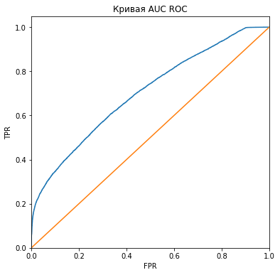

```python
# plot the auc roc curve

precision, recall, thresholds = roc_curve(y_valid, nn_model_preds.detach().numpy())

plt.figure(figsize=(6, 6))
plt.step( precision,recall, where='post')
plt.plot([0.0,1.0],[0.0,1.0])
plt.xlabel('FPR')
plt.ylabel('TPR')
plt.ylim([0.0, 1.05])
plt.xlim([0.0, 1.0])
plt.title('Кривая AUC ROC')
plt.show()
```

**Training of random forest model**

```python
parameters = { 'n_estimators': range (10, 41, 10),
              'max_depth': range (1,40,10)}

model_rf = RandomizedSearchCV(RandomForestClassifier(random_state=12345),parameters,scoring='roc_auc',random_state=12345)
```

```python
model_rf.fit(X_train, y_train)
```

```
RandomizedSearchCV(estimator=RandomForestClassifier(random_state=12345),
                   param_distributions={'max_depth': range(1, 40, 10),
                                        'n_estimators': range(10, 41, 10)},
                   random_state=12345, scoring='roc_auc')
```

```python
print(model_rf.best_params_)
roc_auc_cv_rf = model_rf.best_score_
model_rf.best_score_
```

```
{'n_estimators': 40, 'max_depth': 21}
```

```
0.7239854982152952
```

```python
predictions_rf = model_rf.predict(X_valid)
```

```python
# display auc roc score
probabilities_rf = model_rf.predict_proba(X_valid)
roc_auc_rf = roc_auc_score(y_valid,probabilities_rf[:, 1])
roc_auc_rf
```

```
0.7224588632217692
```

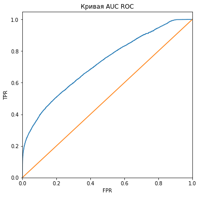

```python
# plot the auc roc curve
precision, recall, thresholds = roc_curve(y_valid, probabilities_rf[:, 1])


plt.figure(figsize=(6, 6))
plt.step( precision,recall, where='post')
plt.plot([0.0,1.0],[0.0,1.0])
plt.xlabel('FPR')
plt.ylabel('TPR')
plt.ylim([0.0, 1.05])
plt.xlim([0.0, 1.0])
plt.title('Кривая AUC ROC')
plt.show()
```

**Training of decision tree model**

```python
parameters = { 'max_depth': range (1,100,10),
             'max_leaf_nodes': list(range(2, 100)),
              'min_samples_split': [2, 3, 4]}

model_dt = RandomizedSearchCV(DecisionTreeClassifier(random_state=12345), parameters, scoring ='roc_auc')
```

```python
model_dt.fit(X_train, y_train)
```

```
RandomizedSearchCV(estimator=DecisionTreeClassifier(random_state=12345),
                   param_distributions={'max_depth': range(1, 100, 10),
                                        'max_leaf_nodes': [2, 3, 4, 5, 6, 7, 8,
                                                           9, 10, 11, 12, 13,
                                                           14, 15, 16, 17, 18,
                                                           19, 20, 21, 22, 23,
                                                           24, 25, 26, 27, 28,
                                                           29, 30, 31, ...],
                                        'min_samples_split': [2, 3, 4]},
                   scoring='roc_auc')
```

```python
print(model_dt.best_params_)
roc_auc_cv_dt = model_dt.best_score_
model_dt.best_score_
```

```
{'min_samples_split': 2, 'max_leaf_nodes': 89, 'max_depth': 31}
```

```
0.7170041072103599
```

```python
predictions_dt = model_dt.predict(X_valid)
```

```python
# display the auc roc score
probabilities_dt = model_dt.predict_proba(X_valid)
roc_auc_dt = roc_auc_score(y_valid,probabilities_dt[:, 1])
roc_auc_dt
```

```
0.7122762133170126
```

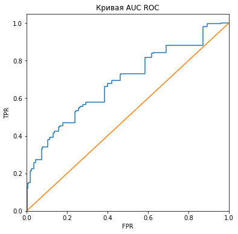

```python
# plot the auc roc curve
precision, recall, thresholds = roc_curve(y_valid, probabilities_dt[:, 1])

plt.figure(figsize=(6, 6))
plt.step( precision,recall, where='post')
plt.plot([0.0,1.0],[0.0,1.0])
plt.xlabel('FPR')
plt.ylabel('TPR')
plt.ylim([0.0, 1.05])
plt.xlim([0.0, 1.0])
plt.title('Кривая AUC ROC')
plt.show()
```

**Selection of best model**

```python
table = ['model_nn','model_rf','model_dt']
```

```python
result = [roc_auc_score_nn,roc_auc_rf,roc_auc_dt]
```

```python
df_result = pd.DataFrame(table,columns = ['model_name'])
```

```python
df_result['roc_auc_score'] = result
```

```python
df_result.sort_values('roc_auc_score',ascending = False)
```

|  | model_name | roc_auc_score |
| --- | --- | --- |
| 1 | model_rf | 0.722459 |
| 2 | model_dt | 0.712276 |
| 0 | model_nn | 0.624202 |

# Analysis of accident factors impact

**best model testing**

```python
predictions_rf_test = model_rf.predict(X_test)
```

```python
probabilities_rf_test = model_rf.predict_proba(X_test)[:, 1]
```

```python
# display the auc roc on test sample
roc_auc_rf_test = roc_auc_score(y_test,probabilities_rf_test)
roc_auc_rf_test
```

```
0.7314310940350061
```

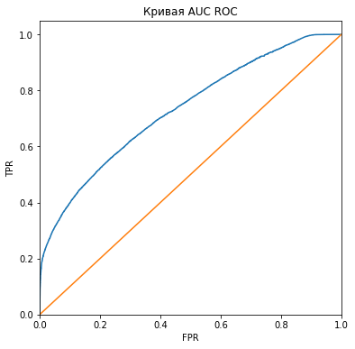

```python
# plot the auc roc curve
precision, recall, thresholds = roc_curve(y_test, probabilities_rf_test)

plt.figure(figsize=(6, 6))
plt.step( precision,recall, where='post')
plt.plot([0.0,1.0],[0.0,1.0])
plt.xlabel('FPR')
plt.ylabel('TPR')
plt.ylim([0.0, 1.05])
plt.xlim([0.0, 1.0])
plt.title('Кривая AUC ROC')
plt.show()
```

**Plot the precision-recall curve**

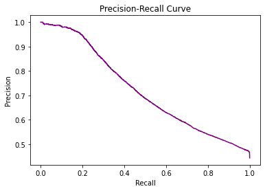

```python
precision, recall, thresholds = precision_recall_curve(y_test, probabilities_rf_test)

fig, ax = plt.subplots()
ax.plot(recall, precision, color='purple')
ax.set_title('Precision-Recall Curve')
ax.set_ylabel('Precision')
ax.set_xlabel('Recall')
plt.show()
```

**Analysis of violations which has impact on the accident possibility**

```python
fault_df = ttl_model_df
```

```python
fault_df = fault_df.drop(columns = ['collision_damage','type_of_collision'])
```

```python
fault_df['at_fault'].sum()
```

```
85547
```

```python
# pivot table qounts the quantity of accidents per violation
factors_count_df = pd.pivot_table(fault_df,values='at_fault',index=['pcf_violation_category'], aggfunc=np.sum).reset_index()
```

```python
factors_count_df.columns= ["fault_factor", "count"]
```

```python
# loop for index change
temp = []
for i in factors_count_df.index:
    temp.append('pcf_violation_category')
factors_count_df.index = temp
```

```python
factors_count_df
```

|  | fault_factor | count |
| --- | --- | --- |
| pcf_violation_category | automobile right of way | 12897 |
| pcf_violation_category | brakes | 19 |
| pcf_violation_category | dui | 6770 |
| pcf_violation_category | fell asleep | 1 |
| pcf_violation_category | following too closely | 2029 |
| pcf_violation_category | hazardous parking | 45 |
| pcf_violation_category | impeding traffic | 54 |
| pcf_violation_category | improper passing | 599 |
| pcf_violation_category | improper turning | 11444 |
| pcf_violation_category | lights | 19 |
| pcf_violation_category | other equipment | 96 |
| pcf_violation_category | other hazardous violation | 735 |
| pcf_violation_category | other improper driving | 309 |
| pcf_violation_category | other than driver (or pedestrian) | 0 |
| pcf_violation_category | pedestrian right of way | 1254 |
| pcf_violation_category | pedestrian violation | 1394 |
| pcf_violation_category | speeding | 32611 |
| pcf_violation_category | traffic signals and signs | 5613 |
| pcf_violation_category | unknown | 51 |
| pcf_violation_category | unsafe lane change | 5054 |
| pcf_violation_category | unsafe starting or backing | 2107 |
| pcf_violation_category | wrong side of road | 2446 |

```python
# loop for cration of column with foult factor anf calculation of percentage of it
for i in fault_df.columns:
    if i == 'at_fault':
        print()
    elif i == 'pcf_violation_category':
        print()
    else:
        temp_df  = pd.pivot_table(fault_df,values='at_fault',
                                                    index=[i],
                                                    aggfunc=np.sum).reset_index()
        temp_df.columns= ["fault_factor", "count"]
        temp_list = []
        for n in temp_df.index:
            temp_list.append(i)
        temp_df.index = temp_list
        factors_count_df = factors_count_df.append(temp_df)
```

```python
factors_count_df['percentage'] = round(factors_count_df['count'] / fault_df['at_fault'].sum()*100,0)
```

```python
factors_count_df.sort_values('count',ascending = False).head(30)
```

|  | fault_factor | count | percentage |
| --- | --- | --- | --- |
| party_drug_physical | G | 84028 | 98.0 |
| cellphone_in_use | 0.0 | 83537 | 98.0 |
| road_surface | dry | 76689 | 90.0 |
| party_sobriety | had not been drinking | 75215 | 88.0 |
| lighting | daylight | 61252 | 72.0 |
| control_device | none | 54866 | 64.0 |
| pcf_violation_category | speeding | 32611 | 38.0 |
| control_device | functioning | 30430 | 36.0 |
| vehicle_age | 3.0 | 15591 | 18.0 |
| lighting | dark with street lights | 14903 | 17.0 |
| pcf_violation_category | automobile right of way | 12897 | 15.0 |
| pcf_violation_category | improper turning | 11444 | 13.0 |
| vehicle_age | 4.0 | 10935 | 13.0 |
| vehicle_age | 5.0 | 9118 | 11.0 |
| vehicle_age | 2.0 | 8406 | 10.0 |
| road_surface | wet | 8336 | 10.0 |
| party_sobriety | had been drinking, under influence | 7150 | 8.0 |
| vehicle_age | 7.0 | 7059 | 8.0 |
| vehicle_age | 6.0 | 7009 | 8.0 |
| pcf_violation_category | dui | 6770 | 8.0 |
| vehicle_age | 8.0 | 6698 | 8.0 |
| lighting | dark with no street lights | 6524 | 8.0 |
| pcf_violation_category | traffic signals and signs | 5613 | 7.0 |
| vehicle_age | 9.0 | 5216 | 6.0 |
| pcf_violation_category | unsafe lane change | 5054 | 6.0 |
| insurance_premium | 19.0 | 3759 | 4.0 |
| insurance_premium | 20.0 | 3569 | 4.0 |
| vehicle_age | 10.0 | 3535 | 4.0 |
| vehicle_age | 0.0 | 3506 | 4.0 |
| insurance_premium | 21.0 | 3397 | 4.0 |

**The highest quantity of accident happends due to the violation of speed limit - 38% случаев.**

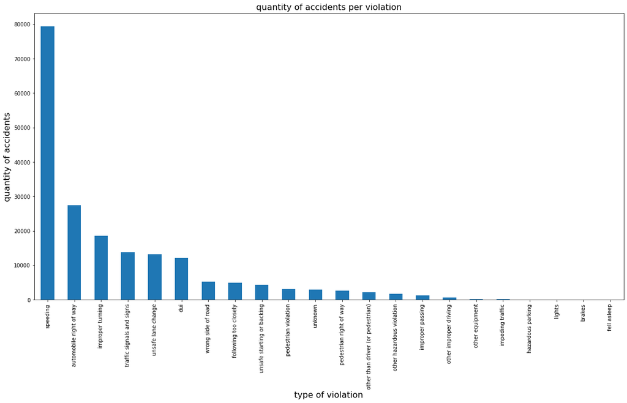

```python
# plottng of quantity of accident per violation
fault_df.groupby('pcf_violation_category')['at_fault'].count().sort_values(ascending = False).plot(kind = 'bar',figsize = (20,10))
plt.title('quantity of accidents per violation', fontsize='16')
plt.xlabel('type of violation', fontsize='16')
plt.ylabel('quantity of accidents', fontsize='16')
```

Proposal: for the reduction of quantity of accident it's possible to develop a software which will not allow user to exceed the speed limit.

# General Conclusion

The best models for the possibility accident prediction is random forest, with auc roc score - 0.72

Development of accident prediction system is possible, but the quantity of factor with affect of the accident is very high. The easiest way to set the parameters which will track the drivers profile and restrict the possibility of car rental in case of any specific violations.

Addition factor which also shall be considered - drivers age, experience, quantity of accidents, etc. (some of data s possible to get from insurance companies in case of partnership.)